# 2. Determine Major Genotypes

Will Hannon

28 April, 2023

As observed by the Cattaneo lab, there are clearly sets of mutations that move together in frequency across every spatial region of the brain. In particular, there are two sets of mutations who’s average frequency appears to add up to 100% in every tissue. These two set of mutations appear to be ancestral to all virus variants in the brain.

The goal of this notebook is to formalize an approach to phase these sets of mutations by clustering variants that have strongly correlated frequencies across multiple tissue samples using k-medoids clustering on a correlation matrix of allele frequency

In this notebook, I identify the ‘genotypes’ `Genome 1` and `Genome 2`. In addition to these two ‘genotypes’, I identify a third set of mutations that appears to arise on `Genome 1`, but is at very low frequency in the Frontal Cortex 2 sample **The output of this notebook is the list of variants annotated by whether they are `Genome 1`, `Genome 2`, `Genome-1-1`, or `subclonal.`**

The inputs for this analysis are (1) the filtered and combined variants from `01-process-variant-calls.Rmd`, (2) annotations of the positions of the MeV open reading frames, and (3) the mutations in the SSPE consensus genome relative to the initial ‘MeVChiTok’ composite D-subtype reference.

```r
## ==== File paths input data ==== ##

if (exists("snakemake")) {

  # Filtered and unified variant calls
  variant.data = snakemake@params[['incsv']]

  # Annotations for the standard Measles ORFs
  annotations.filepath = snakemake@params[['annotations']]

  # Path to the SSPE consensus mutations
  ancestral.data = snakemake@params[['ancestral']]

} else {

  # Filtered and unified variant calls
  variant.data = "../../results/variants/filtered_variants.csv"

  # Annotations for the standard Measles ORFs
  annotations.filepath = "../../config/annotations.csv"

  # Path to the SSPE consensus mutations
  ancestral.data = "../../config/ref/annotated_SSPE_consensus_snps.csv"
}
```

```r
## ==== File paths output data ==== ##

if (exists("snakemake")) {

  # Variant calls annotated "genome-1", "genome-2", "genome-1-1", or "subclonal"
  output.path = snakemake@params[['outcsv']]

  # Path to save figures
  figure.dir = paste0(snakemake@params[['figures']], "/")

} else {

  # Variant calls annotated "genome-1", "genome-2", "genome-1-1", or "subclonal"
  output.path = "../../results/variants/genotyped_variants.csv"

  # Path to save figures
  figure.dir = "../../results/figures/"

}

# Make the figure directory if it doesn't exist
if (!file.exists(figure.dir)) {
  dir.create(figure.dir, recursive = TRUE)
  print("Directory created.")
} else {
  print("Directory already exists.")
}
```

```
## [1] "Directory already exists."
```

## Clusters of Variants

This is what the underlying variant calling data we have looks like.

Filtered Variants

| POS | REF | ALT | AF | DP | Effect | Gene_Name | AA_Change | Accession | Tissue | SNP |
| --- | --- | --- | --- | --- | --- | --- | --- | --- | --- | --- |
| 96 | G | A | 0.0222 | 148636 | NA | N | NA | Temporal_Lobe | Temporal Lobe | G96A |
| 167 | T | C | 0.0270 | 189146 | Synonymous | N | Ile20Ile | Temporal_Lobe | Temporal Lobe | T167C |
| 242 | T | C | 0.0293 | 150211 | Synonymous | N | Ile45Ile | Temporal_Lobe | Temporal Lobe | T242C |
| 366 | T | C | 0.0899 | 185966 | Synonymous | N | Leu87Leu | Temporal_Lobe | Temporal Lobe | T366C |
| 537 | T | C | 0.9056 | 196182 | Missense | N | Ser144Pro | Temporal_Lobe | Temporal Lobe | T537C |
| 810 | G | A | 0.9230 | 171546 | Missense | N | Ala235Thr | Temporal_Lobe | Temporal Lobe | G810A |

It’s clear that there groups of mutations that are found at the same frequency across tissues. This was originally observed in a pilot tissue specimen that was chipped from the frozen brain. This sample is called `SSPE 1`.

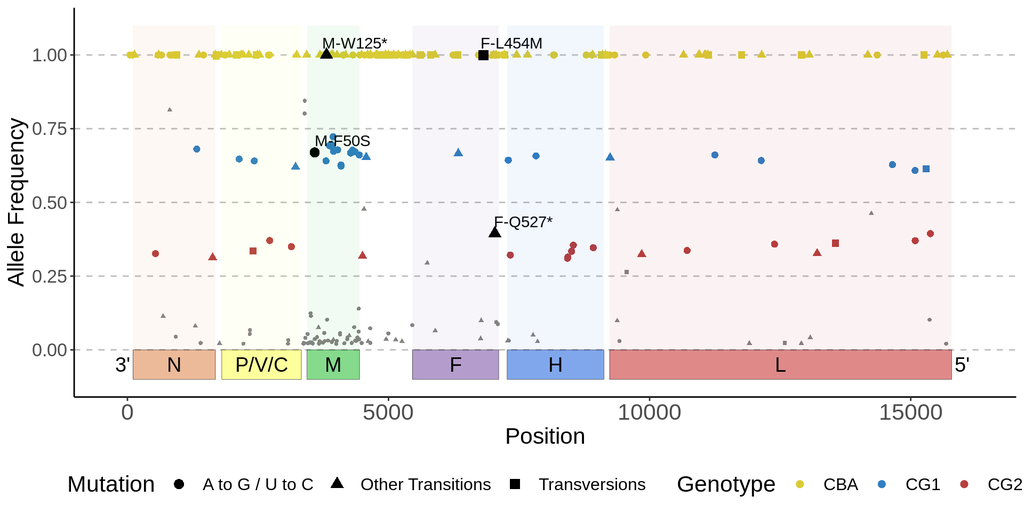

What are the counts of mutations in each of these three bins (`CBA`: “Candidate Brain Ancestor”, `CG1`: “Candidate Genome 1”, and `CG2`: “Candidate Genome 2”)?

Candidate Genotype Variant Counts

| Genotype | n |
| --- | --- |
| CBA | 140 |
| CG1 | 35 |
| CG2 | 21 |
| subclonal | 85 |

These observations are what spurred the following approach to formalize a way to phase the mutations in these genotypes using all 15 tissues.

## Phase Mutation Clusters

We know from experiments and preliminary observations (highlighted above) that there are **at least two sets of mutations present, but not fixed in every tissue sample**. These two sets of mutations are on the background of all viral sequences from this patient. Since these two sets of mutations are in every sample and their frequencies are anti-correlated, we should be able to identify these mutations by clustering them based on their co/anti-correlation.

```
## [1] "There are 63 mutations found in every tissue sample"
```

```r
# Remove the fixed mutations and get the long form of mutations in all samples.
fixed.in.all = selected.variants.df %>%
  filter(SNP %in% all.mutations) %>%
  filter(AF >= 0.95) %>%
  group_by(SNP) %>%
  count() %>%
  filter(n == length(tissues)) %>%
  pull(SNP)

print(paste("There are", length(fixed.in.all), "fixed mutations in every tissue sample that aren't in the reference."))
```

```
## [1] "There are 4 fixed mutations in every tissue sample that aren't in the reference."
```

```r
print(paste("Fixed but not in reference:", fixed.in.all))
```

```
## [1] "Fixed but not in reference: C1699A" "Fixed but not in reference: C1700G"
## [3] "Fixed but not in reference: G1703C" "Fixed but not in reference: G1704C"
```

First, I’ll make a correlation matrix between all of the SNP frequencies for SNPs that are found in every tissue and aren’t fixed in every tissue (i.e. in the reference).

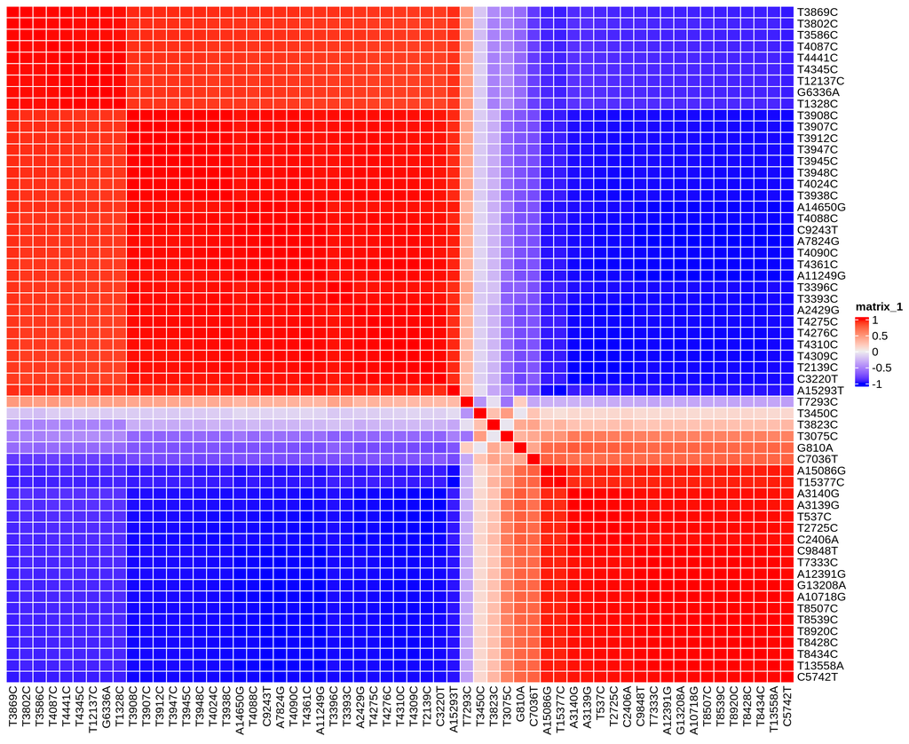

```r
# Convert these mutations to long form where each column is a SNP and the row is it's frequency.
frequency.by.column = selected.variants.df %>%
  filter(SNP %in% all.mutations) %>%
  filter(!SNP %in% fixed.in.all) %>%
  select(AF, SNP, Tissue) %>%
  pivot_wider(names_from = SNP, values_from = AF, values_fill = 0) %>%
  select(!Tissue)

# Calculate R between every pair of columns handling NAs as a correlation matrix
SNP.correlation = cor(frequency.by.column, use="pairwise.complete.obs")

Heatmap(SNP.correlation ,
        rect_gp = gpar(col = "white", lwd = 1),
        column_names_gp = grid::gpar(fontsize = 10),
        row_names_gp = grid::gpar(fontsize = 10),
        show_column_dend = FALSE,
        show_row_dend = FALSE)
```

Most are strongly correlated (or anti-correlated), but some aren’t strongly correlated with one another. Below is a histogram showing this more clearly. I’ll filter out SNPs that aren’t so well correlated with one another to make it easier to cluster the mutations on `Genome-1` and `Genome-2`.

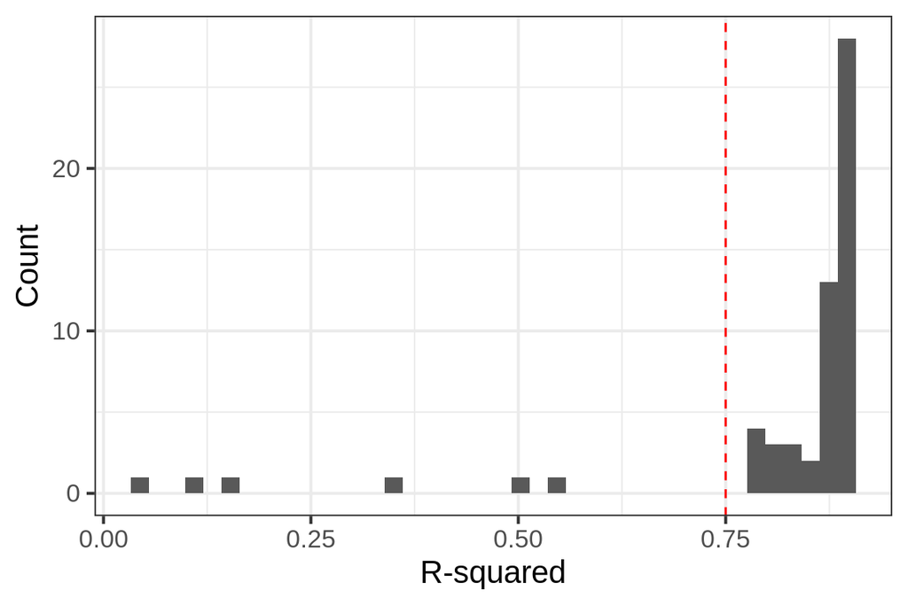

```r
# Take only SNPs with greater than .75 based on the above histogram
filtered.SNPs = rowMeans(SNP.correlation.squared)[rowMeans(SNP.correlation.squared) >= 0.75]

# Remove the fixed mutations and get the long form
filtered.SNPs.df = selected.variants.df %>%
  filter(!SNP %in% fixed.in.all) %>%
  filter(SNP %in% names(filtered.SNPs)) %>%
  select(AF, SNP, Tissue) %>%
  pivot_wider(names_from = SNP, values_from = AF, values_fill = 0) %>%
  select(!Tissue)

# Calculate R between every pair of columns handling NAs
filtered.SNP.correlation = cor(filtered.SNPs.df, use="pairwise.complete.obs")

# Convert to distrance (postive corr is close to 0)
filtered.SNP.dist = as.dist(1 - filtered.SNP.correlation)

# Create k-medoids clustering with 3 clusters
filtered.SNP.kmedoids = pam(filtered.SNP.dist, 3)
kclusters = filtered.SNP.kmedoids$cluster

kclusters.df = data.frame(SNP = names(kclusters), cluster = kclusters)

# Assign the clusters to the original data frame
kmedoids.SNPs = selected.variants.df %>%
  filter(!SNP %in% fixed.in.all) %>%
  filter(SNP %in% all.mutations) %>%
  left_join(., kclusters.df, by = "SNP") %>%
  mutate(cluster = if_else(is.na(cluster), "no cluster", as.character(cluster)))

# Mean of each tissue
tissue.mean = kmedoids.SNPs %>%
  group_by(Tissue, cluster) %>%
  summarize(AF = mean(AF))
```

What’s interesting, is that these mutations aren’t best explained with 2 clusters (i.e. `Genome-1` and `Genome-2`) but rather with *3 clusters*!

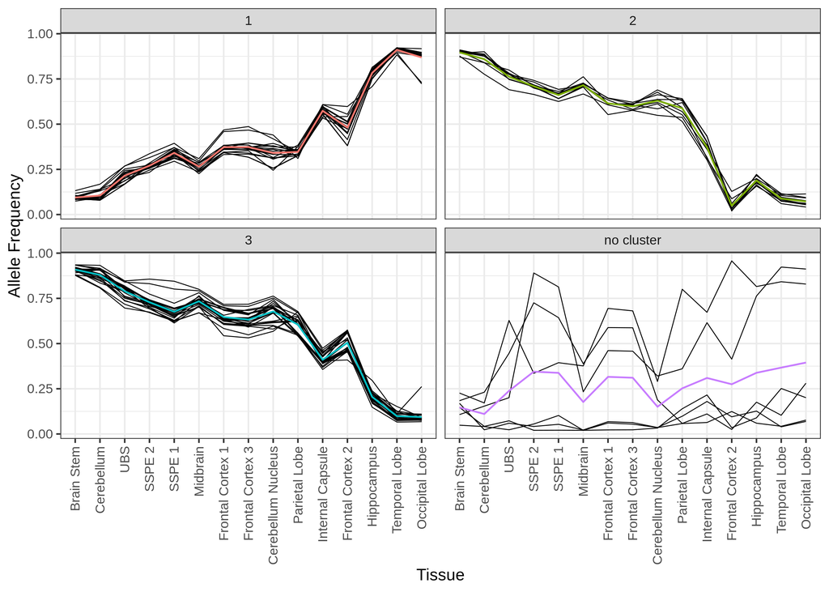

It’s clear from the above plot that mutations grouped in clusters have very similar frequencies across tissues as expected. What’s interesting is that clusters 2 and 3 are found at very similar frequencies in every tissue but the `Frontal Cortex 2` sample. It is likely that this represents an early divergence of one of the major genotypes.

We’ll call cluster 3 `Genome-1`, cluster 2 `Genome-1-1`, and cluster 1 `Genome-2`. The ‘no cluster’ mutations are simply mutations found in every single tissue that don’t neatly fit on `Genome-1`,`Genome-2`, or `Genome-1-1`. These will take some more work to resolve.

```r
g1.SNPs = kmedoids.SNPs %>%
  filter(cluster == 3) %>%
  pull(SNP)

sub.g1.SNPs = kmedoids.SNPs %>%
  filter(cluster == 2) %>%
  pull(SNP)

g2.SNPs = kmedoids.SNPs %>%
  filter(cluster == 1) %>%
  pull(SNP)

labeled.df = selected.variants.df %>%
  filter(!SNP %in% fixed.in.all) %>% # excluding these four odd 'fixed mutations'. These are better explored in IGV
  mutate(Background = case_when(SNP %in% g1.SNPs ~ "genome-1",
                                SNP %in% g2.SNPs ~ "genome-2",
                                SNP %in% sub.g1.SNPs ~ "genome-1",
                                TRUE ~ "subclonal")) %>%
  mutate(Haplotype = case_when(SNP %in% g1.SNPs ~ "genome-1",
                               SNP %in% g2.SNPs ~ "genome-2",
                               SNP %in% sub.g1.SNPs ~ "genome-1-1",
                               TRUE ~ "subclonal"))
```

I’ll write out the newly annotated variant data frame for further analyses.

```
## [1] "Writing the results to results/variants/genotyped_variants.csv"
```

## Exploring Genome-1 and Genome-2

These two clusters of mutations (`Genome-1` and `Genome-2`) are ancestral to all other sequences in the brain. We can see that by summing their frequency in every compartment and seeing that they add up to 1.

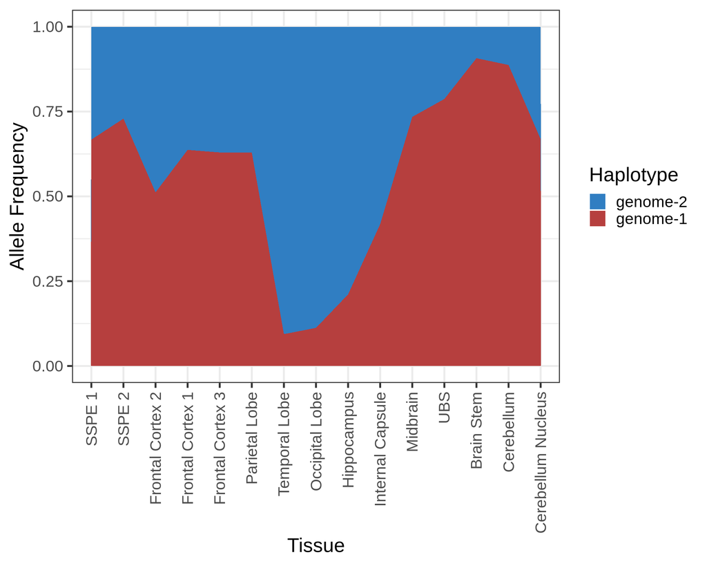

Now, let’s revisit the distribution of mutations in the genome colored by the mutations that have been identified as `Genome-1` or `Genome-2`. We can see how these mutations are distributed in the brain.

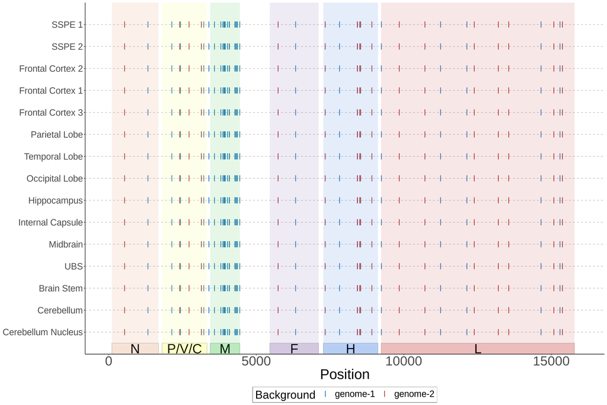

Interestingly, only `Genome-1` has mutations in the Matrix protein. This is kind of surprising given how hyper-mutated the Matrix protein is.

Overall, there are more mutation in `Genome-1` than there are in `Genome-2`, but this is mostly driven by this large block of mutations in the Matrix.

```
## [1] "There are 34 mutations in genome-1 and 19 mutations in genome-2"
```

```
## [1] "There are 13 mutations in genome-1 and 19 mutations in genome-2 when you exclude Matrix"
```

This is very important observation about the haplotypes since Matrix likely accumulates mutations at a different rate than the rest of the genome since there is no selective pressure to maintain the function of Matrix.

## Which mutations don’t cluster?

Some mutations that are present in every tissue aren’t correlating well with either the `Genome-1`, `Genome-2`, or `Genome-1-1` mutations. Let’s take a look at these ’no cluster` mutations.

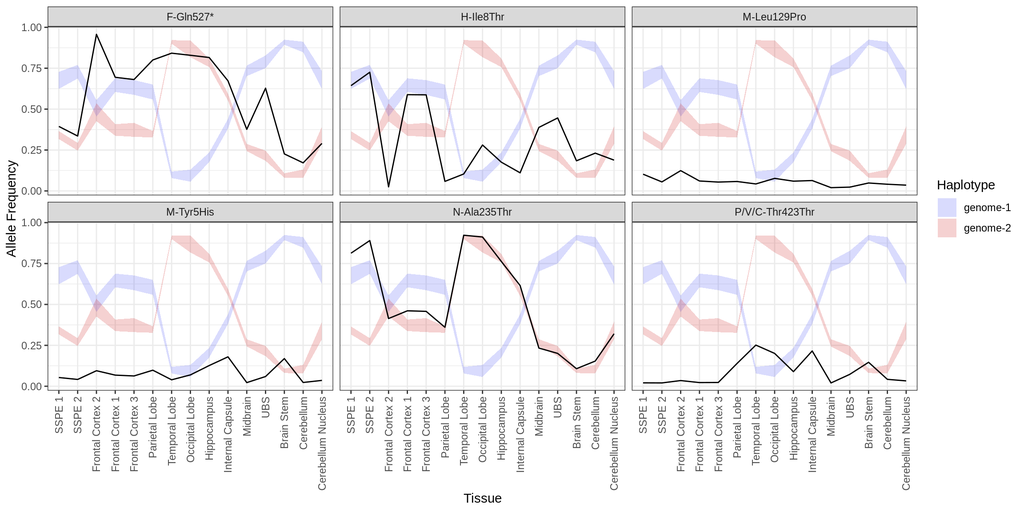

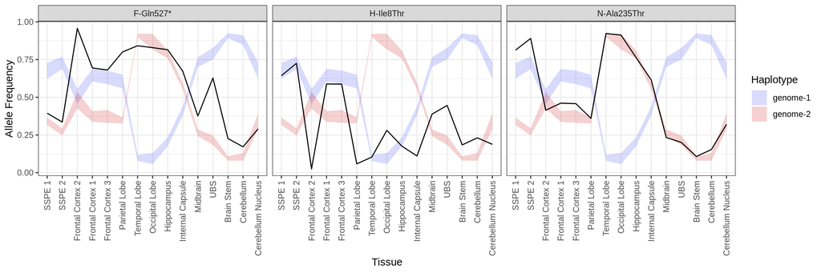

How well did the frequency bins stack up with the real assignments?

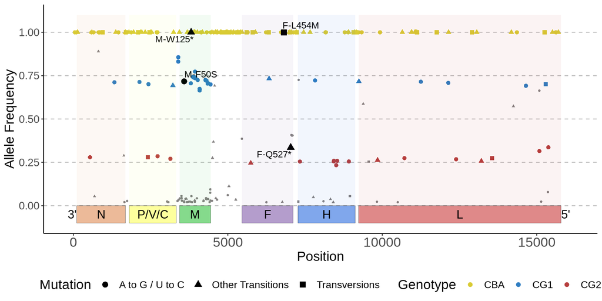